# Group 4 Assignment 3

## (Q3) Random Forest

We used the training and test datasets we created above and the `randomForest` package for this section of the homework. The `randomForest` package requires we make a few additional changes:

- column names in our “dummy value” objects must be valid R variable names
- the function will attempt regression if our response variable is numeric, so we change it back to being a factor

```r
loans_train <- readr::read_rds('data/loans_train.Rds')
loans_test <- readr::read_rds('data/loans_test.Rds')
loans_dv_train <- readr::read_rds('data/loans_dv_train.Rds') %>%
  rename(
    Dependents.3 = `Dependents.3+`,
    Education.NotGraduate = `Education.Not Graduate`) %>%
  mutate(Loan_Status = factor(ifelse(Loan_Status.Y, 'Y', 'N'))) %>%
  select(-Loan_Status.N, -Loan_Status.Y)

loans_dv_test <- readr::read_rds('data/loans_dv_test.Rds') %>%
  rename(
    Dependents.3 = `Dependents.3+`,
    Education.NotGraduate = `Education.Not Graduate`) %>%
  mutate(Loan_Status = factor(ifelse(Loan_Status.Y, 'Y', 'N'))) %>%
  select(-Loan_Status.N, -Loan_Status.Y)
```

The random forest algorithm works well with all sorts of data: numeric and categorical, un-scaled and scaled, full rank and highly correlative. So, we should get similar results if we use the `loans_train` object (which has factor variables in single columns) or the `loans_dv_train` object which splits factor variables into dummy columns **including columns for base levels**.

#### Default model 1 (which has factor variables in single columns)

```r
set.seed(521)
m1 <- randomForest(Loan_Status ~ ., data = loans_train)
print(m1)
```

```
##
## Call:
##  randomForest(formula = Loan_Status ~ ., data = loans_train)
##                Type of random forest: classification
##                      Number of trees: 500
## No. of variables tried at each split: 3
##
##         OOB estimate of  error rate: 19.09%
## Confusion matrix:
##    N   Y class.error
## N 74  70  0.48611111
## Y 18 299  0.05678233
```

#### Default model 2 (which splits factor variables into dummy columns)

```r
set.seed(521)
m1_dv <- randomForest(Loan_Status ~ ., data = loans_dv_train)
print(m1_dv)
```

```
##
## Call:
##  randomForest(formula = Loan_Status ~ ., data = loans_dv_train)
##                Type of random forest: classification
##                      Number of trees: 500
## No. of variables tried at each split: 4
##
##         OOB estimate of  error rate: 19.74%
## Confusion matrix:
##    N   Y class.error
## N 69  75  0.52083333
## Y 16 301  0.05047319
```

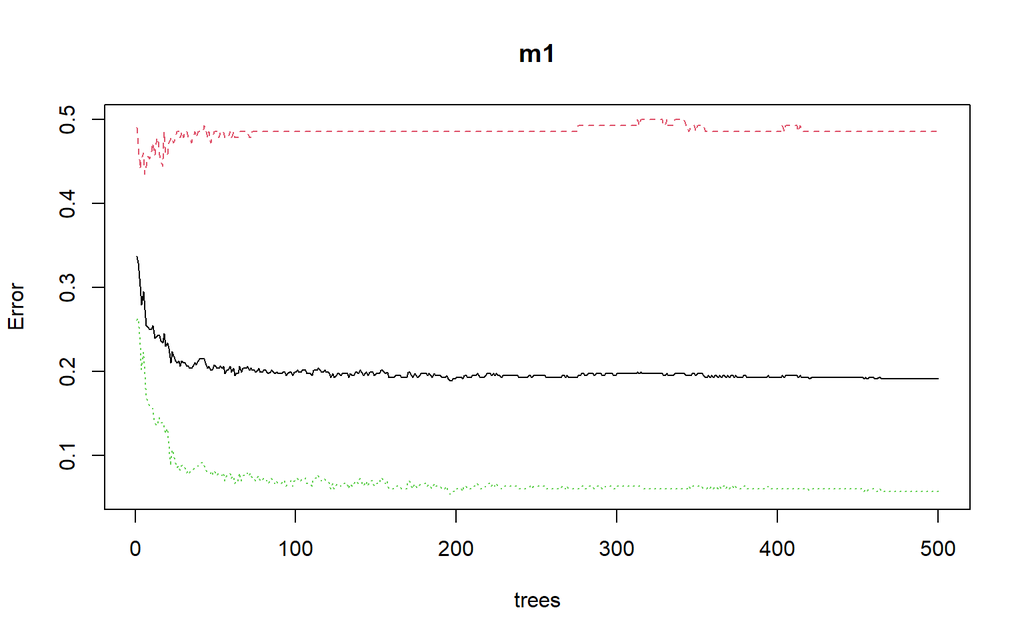

```r
plot(m1)
```

### (Q3) Random Forest - Model based on Model 1 by Tuning Number of Trees (Model 2)

#### Features Highlight

The error rate for the previous model may be unacceptable. The previous model used 500 trees. In the next execution of Random Forest, we try to see if we can reduce the error rate by manipulating the number of trees used. Other indices that we used to determine what could be the optimal model for this exercise are Accuracy, Error Rate, Kappa, and Sensitivity. We ran Model 2 multiple times using ntree parameter for 100, 200, 300, 400, 425, 450, and 475 random trees.

[output not shown]

```r
set.seed(121)
ntreecand = 425
m2 <- randomForest(Loan_Status ~ ., data = loans_train, ntree = ntreecand)
print(m2)
```

```
##
## Call:
##  randomForest(formula = Loan_Status ~ ., data = loans_train, ntree = ntreecand)
##                Type of random forest: classification
##                      Number of trees: 425
## No. of variables tried at each split: 3
##
##         OOB estimate of  error rate: 19.74%
## Confusion matrix:
##    N   Y class.error
## N 73  71  0.49305556
## Y 20 297  0.06309148
```

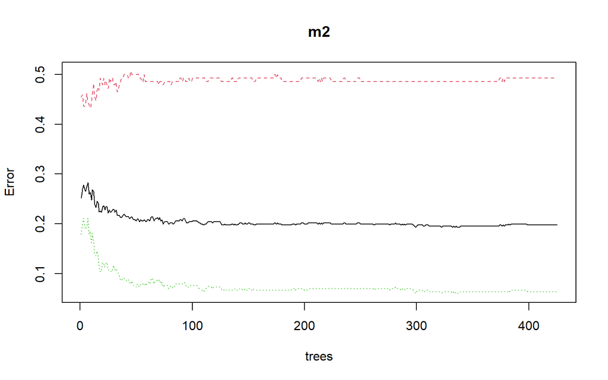

```r
plot(m2)
```

### (Q3) Random Forest - Model based on Optimal Model 2 by Tuning Number of Variables (Model 3)

#### Execution of Random Forest

[output not shown]

```r
set.seed(121)
mtrycand = 3
m3 <- randomForest(Loan_Status ~ ., data = loans_train, ntree = ntreecand, mtry = mtrycand)
print(m3)
```

```
##
## Call:
##  randomForest(formula = Loan_Status ~ ., data = loans_train, ntree = ntreecand,      mtry = mtrycand)
##                Type of random forest: classification
##                      Number of trees: 425
## No. of variables tried at each split: 3
##
##         OOB estimate of  error rate: 19.74%
## Confusion matrix:
##    N   Y class.error
## N 73  71  0.49305556
## Y 20 297  0.06309148
```

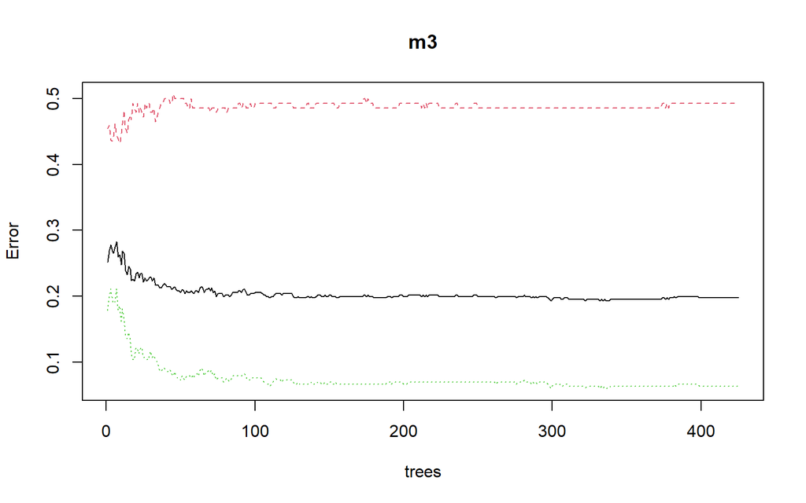

```r
plot(m3)
```

### (Q3) Random Forest - Model Comparison

In the final chore for this exercise, we made predictions on all three generated random forest models and developed the confusion matrix for each. We extracted important values from these models and compared and discussed them.

#### Model 1

```r
prediction1 <- predict(m1,newdata = loans_test)
prediction1.cm <- confusionMatrix(prediction1, loans_test$Loan_Status)
prediction1.cm
```

```
## Confusion Matrix and Statistics
##
##           Reference
## Prediction   N   Y
##          N  27   5
##          Y  21 100
##
##                Accuracy : 0.8301
##                  95% CI : (0.761, 0.8859)
##     No Information Rate : 0.6863
##     P-Value [Acc > NIR] : 4.049e-05
##
##                   Kappa : 0.5661
##
##  Mcnemar's Test P-Value : 0.003264
##
##             Sensitivity : 0.5625
##             Specificity : 0.9524
##          Pos Pred Value : 0.8437
##          Neg Pred Value : 0.8264
##              Prevalence : 0.3137
##          Detection Rate : 0.1765
##    Detection Prevalence : 0.2092
##       Balanced Accuracy : 0.7574
##
##        'Positive' Class : N
##
```

#### Model 2

```r
prediction2 <- predict(m2,newdata = loans_test)
prediction2.cm <- confusionMatrix(prediction2, loans_test$Loan_Status)
prediction2.cm
```

```
## Confusion Matrix and Statistics
##
##           Reference
## Prediction   N   Y
##          N  26   5
##          Y  22 100
##
##                Accuracy : 0.8235
##                  95% CI : (0.7537, 0.8804)
##     No Information Rate : 0.6863
##     P-Value [Acc > NIR] : 9.014e-05
##
##                   Kappa : 0.5466
##
##  Mcnemar's Test P-Value : 0.002076
##
##             Sensitivity : 0.5417
##             Specificity : 0.9524
##          Pos Pred Value : 0.8387
##          Neg Pred Value : 0.8197
##              Prevalence : 0.3137
##          Detection Rate : 0.1699
##    Detection Prevalence : 0.2026
##       Balanced Accuracy : 0.7470
##
##        'Positive' Class : N
##
```

#### Model 3

```r
prediction3 <- predict(m3,newdata = loans_test)
prediction3.cm <- confusionMatrix(prediction3, loans_test$Loan_Status)
prediction3.cm
```

```
## Confusion Matrix and Statistics
##
##           Reference
## Prediction   N   Y
##          N  26   5
##          Y  22 100
##
##                Accuracy : 0.8235
##                  95% CI : (0.7537, 0.8804)
##     No Information Rate : 0.6863
##     P-Value [Acc > NIR] : 9.014e-05
##
##                   Kappa : 0.5466
##
##  Mcnemar's Test P-Value : 0.002076
##
##             Sensitivity : 0.5417
##             Specificity : 0.9524
##          Pos Pred Value : 0.8387
##          Neg Pred Value : 0.8197
##              Prevalence : 0.3137
##          Detection Rate : 0.1699
##    Detection Prevalence : 0.2026
##       Balanced Accuracy : 0.7470
##
##        'Positive' Class : N
##
```

#### Final Comparison

```r
# Model 1 Values
prediction1.accuracy <- prediction1.cm$overall['Accuracy']
prediction1.kappa <- prediction1.cm$overall['Kappa']
prediction1.sensitivity <- prediction1.cm$byClass['Sensitivity']
prediction1.TN <- prediction1.cm$table[1,1]
prediction1.FP <- prediction1.cm$table[1,2]
prediction1.FN <- prediction1.cm$table[2,1]
prediction1.TP <- prediction1.cm$table[2,2]
prediction1.TPR <- prediction1.TP /(prediction1.TP + prediction1.FN)
prediction1.TNR <- prediction1.TN /(prediction1.TN + prediction1.FP)
prediction1.FPR <- prediction1.FP /(prediction1.TN + prediction1.FP)
prediction1.FNR <- prediction1.FN /(prediction1.TP + prediction1.FN)
prediction1.precision <- prediction1.TP / (prediction1.TP + prediction1.FP)
prediction1.recall <- prediction1.TP / (prediction1.TP + prediction1.FN)
prediction1.specificity <- prediction1.TN / (prediction1.TN + prediction1.FP)
prediction1.f1score <- 2 * ((prediction1.precision * prediction1.recall) / (prediction1.precision + prediction1.recall))
```

```r
# Model 2 Values
prediction2.accuracy <- prediction2.cm$overall['Accuracy']
prediction2.kappa <- prediction2.cm$overall['Kappa']
prediction2.sensitivity <- prediction2.cm$byClass['Sensitivity']
prediction2.TN <- prediction2.cm$table[1,1]
prediction2.FP <- prediction2.cm$table[1,2]
prediction2.FN <- prediction2.cm$table[2,1]
prediction2.TP <- prediction2.cm$table[2,2]
prediction2.TPR <- prediction2.TP /(prediction2.TP + prediction2.FN)
prediction2.TNR <- prediction2.TN /(prediction2.TN + prediction2.FP)
prediction2.FPR <- prediction2.FP /(prediction2.TN + prediction2.FP)
prediction2.FNR <- prediction2.FN /(prediction2.TP + prediction2.FN)
prediction2.precision <- prediction2.TP / (prediction2.TP + prediction2.FP)
prediction2.recall <- prediction2.TP / (prediction2.TP + prediction2.FN)
prediction2.specificity <- prediction2.TN / (prediction2.TN + prediction2.FP)
prediction2.f1score <- 2 * ((prediction2.precision * prediction2.recall) / (prediction2.precision + prediction2.recall))
```

```r
# Model 3 Values
prediction3.accuracy <- prediction3.cm$overall['Accuracy']
prediction3.kappa <- prediction3.cm$overall['Kappa']
prediction3.sensitivity <- prediction3.cm$byClass['Sensitivity']
prediction3.TN <- prediction3.cm$table[1,1]
prediction3.FP <- prediction3.cm$table[1,2]
prediction3.FN <- prediction3.cm$table[2,1]
prediction3.TP <- prediction3.cm$table[2,2]
prediction3.TPR <- prediction3.TP /(prediction3.TP + prediction3.FN)
prediction3.TNR <- prediction3.TN /(prediction3.TN + prediction3.FP)
prediction3.FPR <- prediction3.FP /(prediction3.TN + prediction3.FP)
prediction3.FNR <- prediction3.FN /(prediction3.TP + prediction3.FN)
prediction3.precision <- prediction3.TP / (prediction3.TP + prediction3.FP)
prediction3.recall <- prediction3.TP / (prediction3.TP + prediction3.FN)
prediction3.specificity <- prediction3.TN / (prediction3.TN + prediction3.FP)
prediction3.f1score <- 2 * ((prediction3.precision * prediction3.recall) / (prediction3.precision + prediction3.recall))
```

| Model | Accuracy | Kappa | Sensitivity | Recall | Specificity | Precision | F1Score |
| --- | --- | --- | --- | --- | --- | --- | --- |
| Model 1 | 0.8300654 | 0.5660995 | 0.5625000 | 0.8264463 | 0.8437500 | 0.952381 | 0.8849558 |
| Model 2 | 0.8235294 | 0.5465920 | 0.5416667 | 0.8196721 | 0.8387097 | 0.952381 | 0.8810573 |
| Model 3 | 0.8235294 | 0.5465920 | 0.5416667 | 0.8196721 | 0.8387097 | 0.952381 | 0.8810573 |

```r
readr::write_rds(m2, 'output/rf-mod2-model.Rds')
readr::write_rds(prediction2, 'output/rf-mod2-predictions.Rds')
```

## (Q4) Gradient Boosting

We are using the `xgboost` package to answer this question. The `xgboost` package is incredibly powerful and flexible. You can learn more about it and the underlying algorithms here:

- [Rachael Tatman’s tutorial on Kaggle](https://www.kaggle.com/rtatman/machine-learning-with-xgboost-in-r)
- [`xgboost` page on readthedocs.io](https://xgboost.readthedocs.io/en/latest/index.html)

We followed the general steps in the tutorial to answer this question as it is our first time using the `xgboost` package.

1. Prepare the data
2. Run a sample model
3. Tune parameters to select a model with high accuracy and low chance of over-fitting

### Prepare the data

`xgboost` requires data to be in a particular format. The following code shows how to start with the output from the data prep section above and obtain the desired format for the algorithm.

```r
# Load Rds files from data prep section
loans_train     <- readr::read_rds('data/loans_train.Rds')
loans_test      <- readr::read_rds('data/loans_test.Rds')
loans_dv_train  <- readr::read_rds('data/loans_dv_train.Rds')
loans_dv_test   <- readr::read_rds('data/loans_dv_test.Rds')

# xgboost wants predictors and response in separate objects
train_labels <- loans_dv_train$Loan_Status.Y
test_labels <- loans_dv_test$Loan_Status.Y

# We will use this to tell the function to balance the Y/N values
negative_cases <- sum(train_labels == 0)
postive_cases <- sum(train_labels == 1)

# xgboost can use a special xgb.DMatrix object
dtrain <- loans_dv_train %>%
  select(-Loan_Status.N, -Loan_Status.Y) %>%
  as.matrix %>%
  xgb.DMatrix(
    data = .,
    label = loans_dv_train$Loan_Status.Y %>% as.matrix)

# create the same for test data for the predict function
dtest <- loans_dv_test %>%
  select(-Loan_Status.N, -Loan_Status.Y) %>%
  as.matrix %>%
  xgb.DMatrix(
    data = .,
    label = loans_dv_test$Loan_Status.Y %>% as.matrix)
```

### Create a single pre-tuning model

It is always good when using a new method to start with a simple model to make sure everything is working properly.

The following function call includes the smallest number of non-default parameters. (In reality, `scale_pos_weight` is not required, but our labels are slightly imbalanced, so we include it as *mandatory*.)

```r
xgb1 <- xgboost(
  data = dtrain,
  objective = 'binary:logistic',
  eval_metric = 'error',
  scale_pos_weight = negative_cases/postive_cases,
  nrounds = 10)
```

The training error will *always* decrease if we increase the number of iterations. However, the change in error tends to zero. The important question is what does the test error look like with each successive tree?

```r
# Some helper functions
test_error <- function(model, n) {
  pred <- predict(model, newdata = dtest, ntreelimit = n)
  mean(as.numeric(pred > 0.5) != test_labels)
}

test_errors <- function(model) {
  N <- model$niter
  errors <- numeric(N)
  for (i in 1:N) {
    errors[i] <- test_error(model, i)
  }
  return(errors)
}

compare_errors <- function(model) {
  df <- cbind(
    model$evaluation_log %>% as.data.frame(),
    test_errors(model))
  names(df) <- c('iter', 'train_error', 'test_error')
  return(df)
}

# xgb1 errors
compare_errors(xgb1)
```

```
##    iter train_error test_error
## 1     1    0.184382  0.2091503
## 2     2    0.154013  0.2026144
## 3     3    0.134490  0.2287582
## 4     4    0.121475  0.2156863
## 5     5    0.117137  0.2222222
## 6     6    0.121475  0.2222222
## 7     7    0.114967  0.2287582
## 8     8    0.106291  0.2222222
## 9     9    0.106291  0.2287582
## 10   10    0.106291  0.2222222
```

Even at iteration #1 we have evidence of over-fitting. And the test error increases on average as we add more trees. This is most likely because the defaults of `xgboost` allow for a max tree depth of six! Our selected decision model only had a depth of two, so we probably have over-fitting after just one iteration.

### Parameter tuning

There are dozens of parameters one can pass to the `xgboost` function, and we will not attempt to address them all here. The most important for our first foray into `xgboost` are probably the following

- `eta` the scaling factor applied to each iteration, default is 0.3
- `max_depth` controls the maximum size of each tree, default is 6
- `nround` is the number of iterations to run
- `early_stopping_rounds` controls whether to stop before reaching `nrounds`
- `gamma` is described best by the help page: “minimum loss reduction required to make a further partition on a leaf node of the tree. the larger, the more conservative the algorithm will be.”

Through experimentation not included in this write-up, we found that the small size of our data set means we do not need many boosting rounds to hit a plateau in the training accuracy. Therefore, `gamma` is probably not something we need to worry about. (`gamma` will help prevent too many iterations that have little overall impact.) The same argument applies to `early_stopping_rounds`.

The two arguments that make the most sense for us to tune are

- `max_depth` and
- `nround`

### Grid search

We run a grid search for the best combination of `max_depth` and `nround` by letting `max_depth` range from 1 to 5 (we already know 6 is not good) and `nround` range from 1 to 20. In practice, we set `nround` to 20 and only run the algorithm 5 times: once we have a 20-iteration result, we can use a subset of those iterations to accomplish the search.

```r
error_comps <- NULL

for (d in 1:5) {

  # verbose = 0 suppresses interactive output
  mod_d <- xgboost(
    data = dtrain,
    objective = 'binary:logistic',
    eval_metric = 'error',
    scale_pos_weight = negative_cases/postive_cases,
    nrounds = 20,
    max_depth = d,
    verbose = 0)

  error_comps_d <- compare_errors(mod_d)
  error_comps_d$max_depth <- d

  if (is.null(error_comps)) {
    error_comps <- error_comps_d
  } else {
    error_comps <- rbind(error_comps, error_comps_d)
  }
}
```

For each value of `max_depth` the best test errors are shown here:

```r
error_comps %>%
  group_by(max_depth) %>%
  summarize(min_test_error = min(test_error))
```

```
## # A tibble: 5 x 2
##   max_depth min_test_error
##       <int>          <dbl>
## 1         1          0.196
## 2         2          0.163
## 3         3          0.144
## 4         4          0.190
## 5         5          0.183
```

At `max_depth` of three, here are the results:

```r
error_comps %>%
  filter(max_depth == 3) %>%
  select(-max_depth) %>%
  mutate(
    train_error_counts = round(train_error * nrow(dtrain), 0),
    test_error_counts = round(test_error * nrow(dtest), 0))
```

```
##    iter train_error test_error train_error_counts test_error_counts
## 1     1    0.169197  0.1960784                 78                30
## 2     2    0.167028  0.1960784                 77                30
## 3     3    0.156182  0.1960784                 72                30
## 4     4    0.156182  0.1960784                 72                30
## 5     5    0.158351  0.1960784                 73                30
## 6     6    0.158351  0.2026144                 73                31
## 7     7    0.158351  0.2026144                 73                31
## 8     8    0.156182  0.1960784                 72                30
## 9     9    0.156182  0.2026144                 72                31
## 10   10    0.151844  0.2026144                 70                31
## 11   11    0.154013  0.2026144                 71                31
## 12   12    0.147505  0.1830065                 68                28
## 13   13    0.147505  0.1764706                 68                27
## 14   14    0.151844  0.1764706                 70                27
## 15   15    0.145336  0.1633987                 67                25
## 16   16    0.134490  0.1633987                 62                25
## 17   17    0.138829  0.1437908                 64                22
## 18   18    0.132321  0.1699346                 61                26
## 19   19    0.134490  0.1568627                 62                24
## 20   20    0.132321  0.1699346                 61                26
```

It is natural for our errors to move in a choppy way with such a small data set in a classification problem. With a larger data set we would see smoother patterns and a more convincing *minimum* point for our test errors. What we do see with our model is that at iteration 17 we finally get three more observations classified correctly and a low point for our test error.

### Selected parameters

The final model we selected is

```r
xgb_final <- xgboost(
  data = dtrain,
  objective = 'binary:logistic',
  eval_metric = 'error',
  scale_pos_weight = negative_cases/postive_cases,
  nrounds = 17,
  max_depth = 3,
  verbose = 0)
```

Seventeen may seem lot a lot of iterations, but remember each successive tree’s contribution to the whole is only 30%. The first tree carries the most weight by far.

### Interpretation

Boosted trees are not as easy to interpret as single trees, but there are still some things that are helpful. Like a variable importance plot:

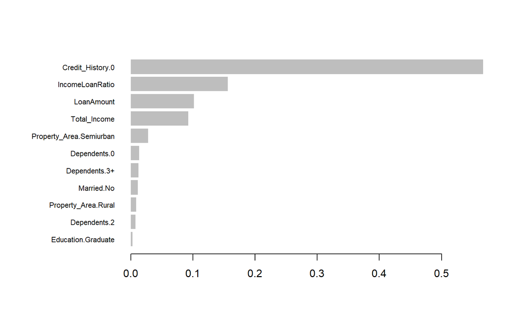

```r
importance_matrix <- xgb.importance(model = xgb_final)
xgb.plot.importance(importance_matrix)
```

The rank of importance agrees with our single-tree analysis, as we’d expect.

```r
readr::write_rds(xgb_final, 'output/xgb-final-model.Rds')
pred_final <- predict(xgb_final, newdata = dtest)
readr::write_rds(pred_final, 'output/xgb-final-predictions.Rds')
```

## (Q5) Model Performance and Selection

### Load RDS

```r
# load rds into session
rds_files = c(paste0("output/", list.files("output")),
              paste0("data/", list.files("data"))) %>%
    grep(pattern = ".rds$", ., ignore.case = TRUE, value = TRUE)

var_names = gsub(pattern = "(output/|data/|.[Rr]ds)", replacement = "", x = rds_files) %>%
    gsub(pattern = "-", replacement = "_", .)

sapply(1:length(rds_files), function(x) assign(var_names[x], readRDS(rds_files[x]), envir = .GlobalEnv)) %>% invisible()
```

### Tidy Models Output

```r
### look at prediction result

# reorder level
loans_test_target <- relevel(loans_test$Loan_Status, ref = "Y")

# decision tree
dt_testing_predictions = relevel(dt_testing_Predictions$.pred_class, ref = "Y")
dt_confusionMatrix = caret::confusionMatrix(dt_testing_predictions, loans_test_target)
dt_confusionMatrix
```

```
## Confusion Matrix and Statistics
##
##           Reference
## Prediction   Y   N
##          Y 100  25
##          N   5  23
##
##                Accuracy : 0.8039
##                  95% CI : (0.7321, 0.8636)
##     No Information Rate : 0.6863
##     P-Value [Acc > NIR] : 0.0007737
##
##                   Kappa : 0.4866
##
##  Mcnemar's Test P-Value : 0.0005226
##
##             Sensitivity : 0.9524
##             Specificity : 0.4792
##          Pos Pred Value : 0.8000
##          Neg Pred Value : 0.8214
##              Prevalence : 0.6863
##          Detection Rate : 0.6536
##    Detection Prevalence : 0.8170
##       Balanced Accuracy : 0.7158
##
##        'Positive' Class : Y
##
```

```r
# random forest
rf_mod2_predictions = relevel(rf_mod2_predictions, ref = "Y")
rf_confusionMatrix = caret::confusionMatrix(rf_mod2_predictions, loans_test_target)
rf_confusionMatrix
```

[output not shown]

```r
# xgb boost
xgb_pred = ifelse(xgb_final_predictions > .5, 'Y', 'N') %>%
    factor(., levels = c("Y", "N"), labels = c("Y", "N"))
xgb_confusionMatrix = caret::confusionMatrix(xgb_pred, loans_test_target)
xgb_confusionMatrix
```

```
## Confusion Matrix and Statistics
##
##           Reference
## Prediction  Y  N
##          Y 97 19
##          N  8 29
##
##                Accuracy : 0.8235
##                  95% CI : (0.7537, 0.8804)
##     No Information Rate : 0.6863
##     P-Value [Acc > NIR] : 9.014e-05
##
##                   Kappa : 0.563
##
##  Mcnemar's Test P-Value : 0.05429
##
##             Sensitivity : 0.9238
##             Specificity : 0.6042
##          Pos Pred Value : 0.8362
##          Neg Pred Value : 0.7838
##              Prevalence : 0.6863
##          Detection Rate : 0.6340
##    Detection Prevalence : 0.7582
##       Balanced Accuracy : 0.7640
##
##        'Positive' Class : Y
##
```

```r
# tidy output
dt_stat = broom::tidy(dt_confusionMatrix)
rf_stat = broom::tidy(rf_confusionMatrix)
xgb_stat = broom::tidy(xgb_confusionMatrix)

model_stat_tidy = dplyr::inner_join(dt_stat %>% dplyr::select(term, `decision tree` = estimate),
                                    rf_stat %>% dplyr::select(term, `random forest` = estimate),
                                    by = "term") %>%
    dplyr::inner_join(., xgb_stat %>% dplyr::select(term, `gradient boosting` = estimate),
                      by = "term")

model_stat_tidy %>% dplyr::filter(term != "mcnemar")
```

```
## # A tibble: 13 x 4
##    term                 `decision tree` `random forest` `gradient boosting`
##    <chr>                          <dbl>           <dbl>               <dbl>
##  1 accuracy                       0.804           0.817               0.824
##  2 kappa                          0.487           0.538               0.563
##  3 sensitivity                    0.952           0.933               0.924
##  4 specificity                    0.479           0.562               0.604
##  5 pos_pred_value                 0.8             0.824               0.836
##  6 neg_pred_value                 0.821           0.794               0.784
##  7 precision                      0.8             0.824               0.836
##  8 recall                         0.952           0.933               0.924
##  9 f1                             0.870           0.875               0.878
## 10 prevalence                     0.686           0.686               0.686
## 11 detection_rate                 0.654           0.641               0.634
## 12 detection_prevalence           0.817           0.778               0.758
## 13 balanced_accuracy              0.716           0.748               0.764
```

For gradient boosting, we focused on tuning two parameters “max_depth” and “nround” for achieving best accuracy. Using a for loop to run for each combination of “max_depth” (1:5) and “nround” (1:20) in a grid search, we used a subset of those 20-iteration to accomplish the search for the best combination of these parameters. At iteration 17, we finally saw a low point in our test error rate. The final model produced a similar conclusion as the decision tree, i.e. pointing to the importance of the “Credit_History” and “IncomeLoanRatio”. The gradient boosting model achieved the best performance among the three algorithms with 82.4% accuracy and Kappa of 56.3%.

The gradient boosting model was clearly the winner among the three based on various metrics. However, the result of decision tree is generally better in terms of interpretability and communication (visually) with various stakeholders. Decision tree algorithm can easily work with numerical and categorical features. It requires very little data preprocessing and it holds no assumptions about the shape of data (thus non-parametric and suitable for fitting various type of data). It also happens to be less affected by multicollinearity compared to other classifiers. However, it tends to be overfitting, and if the data is not well balanced, it can cause significant bias (such as the data set in this assignment, and we tried to resolve this issue by undersampling but with no significant improvement). When one’s data set gets more complex with large number of features, random forest begins to shine and presented to be a better alternative.

Random forest also works easily with numerical and categorical features without much need in data preprocessing. Random forest implicitly performs feature selection and generate uncorrelated decision trees based on choosing a random set of features to build each decision tree. Thus, it is less susceptible by outliers and it can handle linear and non-linear relationships well. Essentially, random forest is to average the results across the multiple decision trees (based on a random subset of input variables) that it builds, thus it can generally provide high accuracy and balance the bias-variance trade-off very well. However, the down side of random forest is that it tends to be less visible or interpretable compared to decision tree. Random forest is not as straightforward as decision tree in communicating the output (such as highlighting specific set of important features) to the stakeholders. In addition, it can be computationally intensive for large data sets.

Similar to random forest, gradient boosting also works like a black box algorithm. Like any other ensemble machine learning procedure, models are built in sequential orders, where later models (or top layers) would correct preceding predictors (from base layers) to arrive at better prediction. Gradient boosting aims at fitting a new predictor in the residual errors committed by the preceding predictor. The errors from prior step are highlighted, and by combining one weak learner to the next learner, the error is reduced significantly over time. The algorithm is less susceptible to overfitting and the result tends to be easy for communication with highlighting important features. The disadvantage is that it can be over sensitive to outliers since every classifier attempts to fix the residual errors generated from prior step. Another disadvantage is the lack of scalability. As one can imagine, the implementation is based on correcting previous predictors, thus making the procedure difficult to streamline. It can be very challenging for large and complex data set.

Each of the machine learning algorithms discussed above shares different pros and cons. For this assignment, gradient boosting is the most preferrable algorithm for this small data set. It is the best classifier in this exercise as reflected by accuracy, Kappa, F1 score, precision, etc. For better result (such as enhancing accuracy and reducing overfitting), future attempts can focus more on feature engineering. For example, while “Credit_History” is obviously important, we come up with the second most important feature in our model, i.e. “IncomeLoanRatio” that holds strong predictive power and it is also highly intuitive.

## Penguins data prep

```r
library(tidyverse)
library(corrplot)
library(palmerpenguins)
penguins <- palmerpenguins::penguins
```

This data has 344 rows of 8 variables:

| variable | definition |
| --- | --- |
| species | a factor denoting penguin species (Adélie, Chinstrap and Gentoo) |
| island | a factor denoting island in Palmer Archipelago, Antarctica (Biscoe, Dream or Torgersen) |
| bill_length_mm | a number denoting bill length (millimeters) |
| bill_depth_mm | a number denoting bill depth (millimeters) |
| flipper_length_mm | an integer denoting flipper length (millimeters) |
| body_mass_g | an integer denoting body mass (grams) |
| sex | a factor denoting penguin sex (female, male) |
| year | an integer denoting the study year (2007, 2008, or 2009) |

```r
summary(penguins)
```

```
##       species          island    bill_length_mm  bill_depth_mm
##  Adelie   :152   Biscoe   :168   Min.   :32.10   Min.   :13.10
##  Chinstrap: 68   Dream    :124   1st Qu.:39.23   1st Qu.:15.60
##  Gentoo   :124   Torgersen: 52   Median :44.45   Median :17.30
##                                  Mean   :43.92   Mean   :17.15
##                                  3rd Qu.:48.50   3rd Qu.:18.70
##                                  Max.   :59.60   Max.   :21.50
##                                  NA's   :2       NA's   :2
##  flipper_length_mm  body_mass_g       sex           year
##  Min.   :172.0     Min.   :2700   female:165   Min.   :2007
##  1st Qu.:190.0     1st Qu.:3550   male  :168   1st Qu.:2007
##  Median :197.0     Median :4050   NA's  : 11   Median :2008
##  Mean   :200.9     Mean   :4202                Mean   :2008
##  3rd Qu.:213.0     3rd Qu.:4750                3rd Qu.:2009
##  Max.   :231.0     Max.   :6300                Max.   :2009
##  NA's   :2         NA's   :2
```

While there are several methods for dealing with missing data, we have opted to simply remove rows with NAs.

- imputing numerical variables with `mean` would decrease variance
- four variables `bill_length_mm`, `bill_depth_mm`, `flipper_length_mm`, and `body_mass_g` have the same number of NAs
- removing rows with NAs treates this variables equally
- variable `sex` has 11 missing data points
- we removed these observations because our data is split evenly between male and female

```r
penguins_na_omit = na.omit(penguins)
```

There is some correlation in the numeric variables, as we have seen in our other assignments.

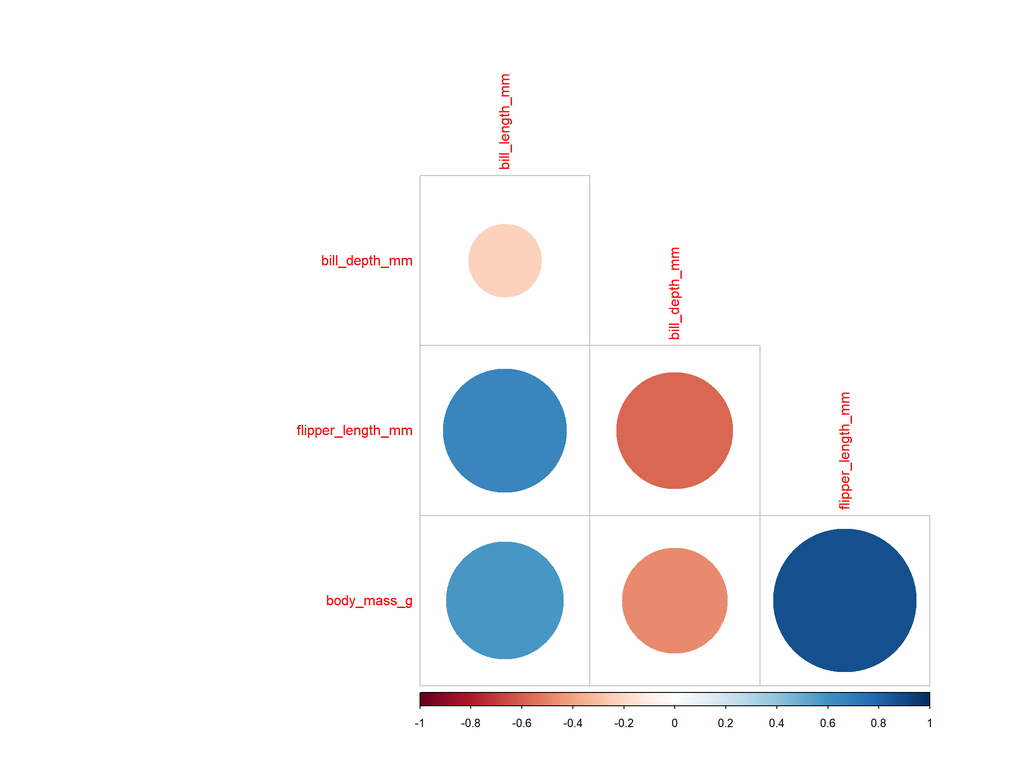

```r
penguins_numeric <- penguins_na_omit %>%
  select(-species, -sex, -island, -year)

# Cor-relation between numerics
corrplot(cor(penguins_numeric), type = 'lower', diag = FALSE)
```

Year is not a potential predictor for this problem so we have excluded it. There is a strong relationship between `body_mass_g` and `flipper_length_mm`. The pairs of measurement variables that have absolute correlations above 0.5 we list here:

```r
corr_matrtix <- cor(penguins_numeric)

corr_matrtix %>%
  as.data.frame %>%
  mutate(x = rownames(corr_matrtix)) %>%
  pivot_longer(
    cols = -x,
    names_to = 'y',
    values_to = 'corr') %>%
  filter(x < y) %>%
  filter(corr > 0.5 | corr < -0.5) %>%
  arrange(desc(abs(corr)))
```

```
## # A tibble: 4 x 3
##   x              y                   corr
##   <chr>          <chr>              <dbl>
## 1 body_mass_g    flipper_length_mm  0.873
## 2 bill_length_mm flipper_length_mm  0.653
## 3 bill_length_mm body_mass_g        0.589
## 4 bill_depth_mm  flipper_length_mm -0.578
```

We save the prepared data for use in Question #1.

```r
readr::write_rds(penguins_na_omit, 'data/penguins_na_omit.Rds')
```